# 10.07 리서치

```
- 클러스터링기법 & 차원축소 방법
```

# 10.08 리서치

```
- 클러스터링 한 후 카테고리의 대표 키워드 추출 방법
- KEY WORD EXTRACTION
- CLUSTER LABELING
- TOPIC LABELING
```

# 10.12 리서치

```
- cluster labeling
```

# 4.10.15 리서치

- tsne 의 차원축소 문제점

# 10.07 리서치

# 클러스터링 기법

## 1. AgglomerativeClustering

[figure not shown]

##### 원리는 두 클러스터 사이의 거리를 측정해서 거리가 가까운 클러스터끼리 묶는 방식

- SIMPLE EXAMPLE

```python
from sklearn.cluster import AgglomerativeClustering
import numpy as np
X = np.array([[1, 2], [1, 4], [1, 0],
...               [4, 2], [4, 4], [4, 0]])
clustering = AgglomerativeClustering().fit(X)
clustering
AgglomerativeClustering()
clustering.labels_
array([1, 1, 1, 0, 0, 0])
# 출처:  https://scikit-learn.org/stable/modules/generated/sklearn.cluster.AgglomerativeClustering.html
```

- SPECIFIC EXAMPLE

```python
cluster = AgglomerativeClustering(n_clusters=number_of_clusters, linkage='ward')
self.labels = cluster.labels_counts = np.bincount(self.labels[self.labels>=0])
self.concepts = {}
for row_id in range(0, len(self.labels)):
    word = self.w2v[row_id][1]
    label = self.labels[row_id]
    if label in self.concepts:
        self.concepts[label].append(word)
    else:
        self.concepts[label] = [word]

return self.concepts
#출처 : https://www.kaggle.com/robin89/concept-modeling-with-word2vec/notebook?select=stage2_test_text.csv.7z
```

## 2. Kmeans

```
1) K Means Clustering with Scikit-learn Library
2) K Means Clustering with NLTK Library
    - euclidean_distance
    - cosine_distance
```

- k-means clustering 은 각 군집이 linearly separable 하거나, 군집의 모양이 구 형태로 convex 할 때 작동한다.
- 단점: 데이터 분포가 복잡할 경우에는 잘 작동하지 않는다

1) *K Means Clustering with Scikit-learn Library*

- SIMPLE EXAMPLE

```python
from sklearn.cluster import KMeans
import numpy as np
X = np.array([[1, 2], [1, 4], [1, 0],
              [10, 2], [10, 4], [10, 0]])
kmeans = KMeans(n_clusters=2, random_state=0).fit(X)
kmeans.labels_

kmeans.predict([[0, 0], [12, 3]])

kmeans.cluster_centers_
#출처 : https://scikit-learn.org/stable/modules/generated/sklearn.cluster.KMeans.html#sklearn.cluster.KMeans
```

- SPECIFIC EXAMPLE

```python
cluster = KMeans(n_clusters=number_of_clusters, random_state=0).fit(self.w2vecarrays)
self.labels = cluster.labels_counts = np.bincount(self.labels[self.labels>=0])
self.concepts = {}
for row_id in range(0, len(self.labels)):
    word = self.w2v[row_id][1]
    label = self.labels[row_id]
    if label in self.concepts:
        self.concepts[label].append(word)
    else:
        self.concepts[label] = [word]

return self.concepts
#출처 : https://www.kaggle.com/robin89/concept-modeling-with-word2vec/notebook?select=stage2_test_text.csv.7z
```

2) *K Means Clustering with NLTK Library*

##### Euclidean_distance

```python
def euclidean_distance(u, v):
    """
    Returns the euclidean distance between vectors u and v. This is equivalent
    to the length of the vector (u - v).
    """
    diff = u - v
    return sqrt(numpy.dot(diff, diff))
```

```python
# model = Word2Vec(sentences, min_count=1)
# X = model[model.vocab]
from nltk.cluster import KMeansClusterer
import nltk
NUM_CLUSTERS=3
kclusterer = KMeansClusterer(NUM_CLUSTERS, distance=nltk.cluster.util.euclidean_distance, repeats=25)
assigned_clusters = kclusterer.cluster(X, assign_clusters=True)
print (assigned_clusters)
# output: [0, 2, 1, 2, 2, 1, 2, 2, 0, 1, 0, 1, 2, 1, 2]
```

##### cosine_distance

```python
def cosine_distance(u, v):
    """
    Returns 1 minus the cosine of the angle between vectors v and u. This is
    equal to 1 - (u.v / |u||v|).
    """
    return 1 - (numpy.dot(u, v) / (sqrt(numpy.dot(u, u)) * sqrt(numpy.dot(v, v))))
```

```python
# model = Word2Vec(sentences, min_count=1)
# X = model[model.vocab]
from nltk.cluster import KMeansClusterer
import nltk
NUM_CLUSTERS=3
kclusterer = KMeansClusterer(NUM_CLUSTERS, distance=nltk.cluster.util.cosine_distance, repeats=25)
assigned_clusters = kclusterer.cluster(X, assign_clusters=True)
print (assigned_clusters)
# output: [0, 2, 1, 2, 2, 1, 2, 2, 0, 1, 0, 1, 2, 1, 2]
```

## 3. KMeansEnsemble

##### 여러 번의 k-means 학습 결과를 통하여 점들 간의 co-occurrence 를 학습하고, 이를 affinity matrix 로 이용하여 agglomerative clustering 을 수행하는 방법

- n_clusters : 최종적으로 학습하고 싶은 군집의 개수
- n_ensembles : 기본 k-means 의 반복 학습 횟수
- n_ensemble_units (n_units) : 기본 k-means 학습 시의 k 값

#### KMeansEnsemble

```python
from kmeans_ensemble import KMeansEnsemble

n_clusters = 2
n_ensembles = 1000
n_units = 100
n_data = X.shape[0]

kmeans_ensemble = KMeansEnsemble(n_clusters, n_ensembles, n_units)
labels = kmeans_ensemble.fit_predict(X)
```

#### output

```python
Iteration 1000 / 1000 was done
Agglomerative clustering iters = 998 was done
```

#### Sparsity계산

```python
nnz = kmeans_ensemble.affinity.nnz
sparsity = 1 - ((n_data + nnz) / (n_data ** 2))
print('sparsity of affinity = {:.4}'.format(sparsity))
```

#### output

```python
sparsity of affinity = 0.9709
```

```python
# 참고
https://github.com/lovit/kmeans_ensemble
```

## 4.DBSCAN

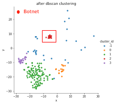

- 클러스터의 갯수를 미리 지정하지 않는 군집 알고리즘이다.
- DBSCAN은 병합 군집이나 k-평균보다는 다소 느리지만 비교적 큰 데이터셋에도 적용한다
- 데이터의 밀집지역이 한 클러스터를 구성하며 비교적 비어있는 지역을 경계로 다른 클러스터와 구분한다. DBSCAN은 특성 공간에서 가까이 있는 데이터가 많아 붐비는 지역의 포인트를 찾는다.
- SIMPLE EXAMPLE 1

```python
# DBSCAN 알고리즘 적용
    dbscan = DBSCAN(eps=eps, min_samples=min_sample)
    clusters = dbscan.fit_predict(word_vector)
```

- SIMPLE EXAMPLE 2

```python
from sklearn.cluster import DBSCAN
import numpy as np
X = np.array([[1, 2], [2, 2], [2, 3],
              [8, 7], [8, 8], [25, 80]])
clustering = DBSCAN(eps=3, min_samples=2).fit(X)
clustering.labels_

clustering
출처: https://scikit-learn.org/stable/modules/generated/sklearn.cluster.DBSCAN.html#sklearn.cluster.DBSCAN
```

- SPECIFIC EXAMPLE

```python
cluster = DBSCAN(eps=0.01, min_samples=3).fit(self.w2vecarrays)
self.labels = cluster.labels_counts = np.bincount(self.labels[self.labels>=0])
self.concepts = {}
for row_id in range(0, len(self.labels)):
    word = self.w2v[row_id][1]
    label = self.labels[row_id]
    if label in self.concepts:
        self.concepts[label].append(word)
    else:
        self.concepts[label] = [word]

return self.concepts
#출처 : https://www.kaggle.com/robin89/concept-modeling-with-word2vec/notebook?select=stage2_test_text.csv.7z
```

# 차원축소

### 1.TSNE

- 고차원 데이터를 축소하여 시각화 하는 용도로 주로 사용하는 알고리즘이다.
- PCA와 다른 점은, 고차원의 피처가 가지고 있는 분포 기반의 hidden factor를 아주 잘 잡아낸다.

```python
def visualize(self):
        x_arr =np.array([i[0] for i in self.arrays])
        tsne = TSNE(n_components=2)
        X_tsne = tsne.fit_transform(x_arr)

        plt.figure(figsize=(200, 200), dpi=100)
        max_x = np.amax(X_tsne, axis=0)[0]
        max_y = np.amax(X_tsne, axis=0)[1]
        plt.xlim((-max_x,max_x))
        plt.ylim((-max_y,max_y))


        for row_id in range(0, len(self.arrays)):
            target_word = self.arrays[row_id][1]
            x = X_tsne[row_id, 0]
            y = X_tsne[row_id, 1]
            plt.annotate(target_word, (x,y))
#출처 : https://www.kaggle.com/robin89/concept-modeling-with-word2vec/notebook?select=stage2_test_text.csv.7z
```

## 2.PCA

- 특성들이 통계적으로 상관관계가 없도록 데이터셋을 회전시키는 기술로서 특성들의 상관관계가 가장 큰 방향(분산이 가장 큰 방향)을 찾고 그 방향과 직각인 방향 중에서 가장 많은 정보를 담은 방향을 찾아낸다.
- 단점 : 성능이 그렇게 뛰어난 편이 아니다.

```python
#SIMPLE CODE
#INPUT
from sklearn.decomposition import PCA
pca = PCA(n_components=40)
pca.fit(pca_data)
```

```python
#OUTPUT
PCA(copy=True, iterated_power='auto', n_components=40, random_state=None,
  svd_solver='auto', tol=0.0, whiten=False)
```

```python
#SIMPLE CODE
#INPUT
pca.fit_transform(pca_data)
```

```python
#OUTPUT
array([[  1.53447146e+00,   3.39023873e+00,   1.08127260e-01, ...,
          2.01060983e+00,   1.28154938e+00,  -1.75942159e+00],
       [  6.18207164e-01,   3.42729725e+00,   2.81663213e+00, ...,
          2.55504965e-01,   1.54289260e+00,   7.97892561e-01],
       [  1.88674743e+00,   3.41535169e+00,   4.73622261e+00, ...,
          1.86097684e+00,   1.52052731e+00,   1.40849692e+00],
       ...,
       [ -3.77297627e-01,   6.06470989e-02,  -3.92401039e-02, ...,
         -1.30437759e-02,   4.79383547e-03,  -8.41005516e-03],
       [ -3.98396248e-01,   1.31898811e-02,  -3.59753547e-02, ...,
         -1.45744723e-02,   6.89606871e-03,   1.00892222e-02],
       [ -2.46134171e-01,  -7.74727566e-03,  -1.64871864e-02, ...,
         -3.79921235e-03,  -4.07326473e-03,  -1.65871335e-02]])
```

```python
pca_40 = pca.fit_transform(pca_data)
```

```python
#출처 : http://textmining.kr/?p=420
```

```python
#출처: https://scikit-learn.org/stable/modules/generated/sklearn.decomposition.PCA.html?highlight=pca#sklearn.decomposition.PCA
```

## 3.SVD

- 데이터가 linear한 상황에서만 잘 동작한다.
- white space가 아주 많은 행렬에 대해서는 거의 최악에 가까운 성능을 보여준다.
- k파라미터가 증가할수록 오차도 같이 증가하는 기이한 현상이 있다.
- Singular Value Decomposition(SVD; 특이값 분해)에 기반한 방법.

#### sklearn의 PCA는 SVD로 구현되었음

코드는pca와동일하다

# 10.08 리서치

키워드의 기준은 두 가지다.

- 첫째는 한 토픽의 키워드라면, 각 토픽에 속한 많은 문서들에서 등장해야 합니다.
- 둘째는 차별성이 없는 단어는 키워드로 부적합합니다.
- 첫번째와 두번째를 모두 고려하여 키워드를 선택해야 한다.

## 1.Topic labeling

### LDA

- 특징
  - 두 관점의 중요도를 사람이 직접 정할 수 있도록 한다
  - 알고리즘이 키워드를 선택하지 않고 사람이 조절 가능
  - 해석의 여지를 의도적으로 사람에게 주었다.

### SPECIFIC EXAMPLE

```python
## Classification combining LDA and Word2Vec
```

출처 : https://www.kaggle.com/vukglisovic/classification-combining-lda-and-word2vec

```python
## word2vec --> vector -> topic modeling(LDA) 이용
```

```python
LDAmodel = LdaMulticore(corpus=corpus,
                        id2word=dictionary,
                        num_topics=num_topics,
                        workers=4,
                        chunksize=4000,
                        passes=7,
                        alpha='asymmetric')
```

```python
def document_to_lda_features(lda_model, document):
    """ Transforms a bag of words document to features.
    It returns the proportion of how much each topic was
    present in the document.
    """
    topic_importances = LDAmodel.get_document_topics(document, minimum_probability=0)
    topic_importances = np.array(topic_importances)
    return topic_importances[:,1]
```

```python
def get_topic_top_words(lda_model, topic_id, nr_top_words=5):
    """ Returns the top words for topic_id from lda_model.
    """
    id_tuples = lda_model.get_topic_terms(topic_id, topn=nr_top_words)
    word_ids = np.array(id_tuples)[:,0]
    words = map(lambda id_: lda_model.id2word[id_], word_ids)
    return words
```

```python
""" OUTPUT예시
Looking up top words from top topics from EAP.
For topic 0, the top words are: though, one, natur, made, would.
For topic 1, the top words are: ?, may, upon, time, one.
For topic 19, the top words are: mr, six, five, foot, hundr.
For topic 42, the top words are: said, dupin, shoulder, ?, eye.
For topic 110, the top words are: nt, ?, think, realli, fli.

Looking up top words from top topics from HPL.
For topic 0, the top words are: though, one, natur, made, would.
For topic 2, the top words are: could, upon, ?, old, one.
For topic 9, the top words are: friend, love, heard, upon, seem.
For topic 85, the top words are: shall, night, perfect, sleep, anxieti.
For topic 110, the top words are: nt, ?, think, realli, fli.

Looking up top words from top topics from MWS.
For topic 69, the top words are: hope, gone, pass, boat, would.
For topic 78, the top words are: raymond, perdita, lord, frequent, ad.
For topic 125, the top words are: calm, frame, breath, elizabeth, bless.
For topic 136, the top words are: resolv, passion, tear, joy, love.
For topic 142, the top words are: evil, tell, love, might, ?."""
```

## 2.Keyword extraction

출처https://postfiles.pstatic.net/MjAyMDEwMDhfMjg2/MDAxNjAyMTQxMzUwMTg2.FldwuVaHVe4svbVt9GSN_dQ7XgFHge3tqr4szDdQQTsg.4Ghk22JFYmLKBRuYpxBlu9rghoUX3Fb1rqFa6QidmZkg.JPEG.ayeji9/%EC%BA%A1%EC%B2%983.JPG?type=w580

### SPECIFIC EXAMPLE

- 사용한 word embedding 모델 : Word2vec(skip-gram)
- Word Embedding 모델을 통해 의미적 유사도 기반의 키워드를 선택

##### 실험 주제 : 웹사이트에서 키워드 뽑기

- Word Embedding 모델을 통해 웹사이트 프로파일 과 후보키워드와의 의미적 유사도 계산을 통 해 후보키워드를 선택한다. 프로파일 과정에 서 추출 된 키워드는 주제성을 내포하고 있지 않는 키워드가 포함되어 있을 수 있기 때문에 후보 키워드를 선택함으로써 주제성을 내포하 고 있지 않는 키워드를 제거한다. 후보 키워드 는 사전에 의미적 키워드 위주로 구축하였다. 마지막으로 필터링 과정에서는 키워드 선택 과정에서 선택 된 키워드 중 후보 키워드와의 유사도는 높지만 문서와는 일관성이 없는 키워 드가 선택될 수 있다. 따라서 선택 된 후보 키워 드 중 일관성 없는 키워드를 제거하기 위해서 모든 후보키워드 쌍의 대해 의미적 유사도를 계산하고 일관성 없는 키워드를 제거하고 최종 키워드를 추출한다

```python
## 출처: http://pdf.xuebalib.com:1262/1fupYdWTbSfu.pdf
```

### TEXT RANK 알고리즘

출처 : http://pdf.xuebalib.com:1262/1fupYdWTbSfu.pdf

논문제목: Research on Keyword Extraction Based on Word2Vec Weighted TextRank

- key word 추출 알고리즘 하나인 알고리즘
- 키워드 추출 기능과 핵심 문장 추출 기능, 두 가지를 제공한다.
- word graph 나 sentence graph 를 구축한 뒤, Graph ranking 알고리즘인 PageRank 를 이용하여 각각 키워드와 핵심 문장을 선택합니다.
- 키워드에 변화가 있다면 정확도가 높아진다.

## 3.Cluster labeling

### SPECIFIC EXAMPLE

출처https://www.koreascience.or.kr/article/JAKO201833469090754.pdf :

- 각 군집화에 있는 단어들의 TF-IDF 값과 Word2Vec를 통하여 획득할 수 있는 각 단어들 간 의 유사도 분석을 하여 획득한 단어들로 해당 군집화의 대표 단어들을 선정해준다.
- ArgMaxValue 각 단어의 TF-IDF의 값과 Word2Vec에서 제공해주는 다른 단어와의 유사도 값을 합산하여 구한다. 그 후 최고점을 획득한 군집화내 의 단어 중 3, 4개를 대표단어로 선정
- 실험 개요 : 네이버 블로그 주제어 뽑기

[figure not shown]

### soyclustering

- 문서 군집화를 위한 spherical k-means 알고리즘과 centroid 기반한다.
- cluster labeling algorithm을 제공한다.
- clustering labeling 기능 을 제공한다.
- keywords score 는 한 단어가 속한 군집에서의 등장 비율이 다른 군집에서의 등장 비율보다 얼마나 높은지, 그 비율을 keyword score 로 이용한다.

##### simle example

from soyclustering import proportion_keywords

출처: https://pypi.org/project/soyclustering/

# 10.12 리서치

# cluster labeling

### 1.kemans.cluster*centers* 사용

```python
#예제코드
#1.각데이터 포인트의 레이블을 찾는다
labels=kmeans.labels_
# 2. 각클러스터에서 샘플수를 찾는다.
np.unique(labels, return_counts=True)
## 3. 클러스터 센터를 찾는다.
kmeans.cluster_centers_
```

- 단점 : 고양이,강아지,거북이가 있는데 동물이 대표 키워드이지만 고양이가 키워드로 추출될 수 있다. 하지만 고양이,강아지,거북이,동물이 클러스터 안에 있다면 동물이 키워드로 추출된다.
- 장점: 계산이 복잡하지 않다.

### 2.pairwise_distances_argmin_min 사용

```python
# 클러스터 안에서 가장 중심에 가까운 단어를 키워드라고 지정한다.
```

```python
from sklearn.metrics import pairwise_distances_argmin_min
```

```python
m_km = KMeans(n_clusters=num_clusters)
m_km.fit(tf_matrix)
m_clusters = m_km.labels_.tolist()

centers = np.array(m_km.cluster_centers_)

closest_data = []
for i in range(num_clusters):
    center_vec = centers[i]
    data_idx_within_i_cluster = [ idx for idx, clu_num in enumerate(m_clusters) if clu_num == i ]

    one_cluster_tf_matrix = np.zeros( (  len(data_idx_within_i_cluster) , centers.shape[1] ) )
    for row_num, data_idx in enumerate(data_idx_within_i_cluster):
        one_row = tf_matrix[data_idx]
        one_cluster_tf_matrix[row_num] = one_row

    closest, _ = pairwise_distances_argmin_min(center_vec, one_cluster_tf_matrix)
    closest_idx_in_one_cluster_tf_matrix = closest[0]
    closest_data_row_num = data_idx_within_i_cluster[closest_idx_in_one_cluster_tf_matrix]
    data_id = all_data[closest_data_row_num]

    closest_data.append(data_id)

closest_data = list(set(closest_data))
```

## 3. scipy.cluster사용

```python
# pairwise_distances_argmin_min과 비슷함
```

```python
from scipy.cluster.vq import vq

# centroids: N-dimensional array with your centroids
# points:    N-dimensional array with your data points

closest, distances = vq(centroids, points)
```

```python
## 출처
## https://docs.scipy.org/doc/scipy/reference/cluster.vq.html
```

출처

- 문서 클러스터를 위한 워드넷기반의 대표 레이블 선정 방법 - JICSwww.jics.or.kr › manuscript › file › JICS-2017-18-2-007

## 4. cluster labeling Hypernymy이용

### L 집합에서 단어를 4가지로 분류해준다.

```
- FreqKey: Choose the l most frequent hypernyms of the l most frequent keywords.
-  CentKey: Choose the l most central hypernyms of the l most central keywords.
-  FreqHyp: Choose the l most frequent hypernyms.
-  CentHyp: Choose the l most central hypernyms.
```

[figure not shown]

```python
## 출처 https://www.aclweb.org/anthology/U18-1008.pdf
```

```python
## 후보레이블을 만드는 이유
```

- 후보 레이블을 식별하지 않을 경우 모든 단어 중에서 대표 레이블을 선정해야 하므로 그 범위가 너무 넓어 계산량이 많아지므로 후보 레이블 선정을 통 해 문서 클러스터와 관련된 단어로 대표 레이블의 후보 를 식별해야 한다.
- freqkey와 freqhyp는 집합에서 얼마나 자주 출연하는지에 대한 빈도로 판단한다.
- centerykey와 centphy 는 cluster 의 센터에 의해 계산된다.
- cluster center를 찾을때 centhyp에 의해 결정이 된다.
- LABEL은 아래의 거리의 방식에서 거리 순으로 선택된다.

###### 거리측정방식

- The distance between hypernym h and the cluster’s center is
  - d(−→h , −→K) = ||−→h −−→K||, where −→h is the average vector of the hypernym’s component words.

# 10.15 리서치

## 1. tsne에 2차원이상은 어려운가?

### 어렵다는 의견 1

```python
## 원문 http://www.cs.toronto.edu/~hinton/absps/tsne.pdf
```

Dimensionality reduction for other purposes. It is not obvious how t-SNE will perform on the more general task of dimensionality reduction (i.e., when the dimensionality of the data is not reduced to two or three, but to d > 3 dimensions). To simplify evaluation issues, this paper only considers the use of t-SNE for data visualization. The behavior of t-SNE when reducing data to two or three dimensions cannot readily be extrapolated to d > 3 dimensions because of the heavy tails of the Student-t distribution. In high-dimensional spaces, the heavy tails comprise a relatively large portion of the probability mass under the Student-t distribution, which might lead to d-dimensional data representations that do not preserve the local structure of the data as well. Hence, for tasks in which the dimensionality of the data needs to be reduced to a dimensionality higher than three, Student t-distributions with more than one degree of freedom10 are likely to be more appropriate.

### 어렵다는 의견2

```python
## 원문 : https://www.datacamp.com/community/tutorials/introduction-t-sne
```

It is highly recommended to use another dimensionality reduction method (e.g., PCA for dense data or TruncatedSVD for sparse data) to reduce the number of dimensions to a reasonable amount (e.g., 50) if the number of features is very high. This will suppress some noise and speed up the computation of pairwise distances between samples.

##### 요약

```
- 어렵다
- 시간이 너무 오래 걸린다.
- 50차원 쯤으로 낮출 때 pca나 다른방법으로 사용하여라라고 tsne 공식문서에 명시되어있다.
```

## 대체방안

### ||. umap 사용

[figure not shown]

### |. pca 사용

```python
##  대부분 3차원 이상은 pca를 사용하여 차원축소를 한다.
```

```python
## 출처: https://towardsdatascience.com/visualising-high-dimensional-datasets-using-pca-and-t-sne-in-python-8ef87e7915b
```

```python
pca_50 = PCA(n_components=50)
pca_result_50 = pca_50.fit_transform(data_subset)
print('Cumulative explained variation for 50 principal components: {}'.format(np.sum(pca_50.explained_variance_ratio_)))
[out] Cumulative explained variation for 50 principal components: 0.8267618822147329
```

### ||.umap사용

- Uniform Manifold Approximation and Projection
- 대규모 데이터를 위한 효율적인 차원축소방법
- Similar to t-SNE but can also be used for non-linear dimension reduction

```python
## 공식 문서에서 차원을 50차원으로 낮추는 상황에도  사용가능하다고 적혀있음
```

If you are interested in (density based) clustering, or other machine learning techniques, it can be beneficial to pick a larger embedding dimension (say 10, or 50) closer to the the dimension of the underlying manifold on which your data lies.

```python
## 요약 : 클러스터를 위해 10 or more을 사용해도 적당하다.
## 출처 : https://umap-learn.readthedocs.io/en/latest/parameters.html
```

### example

```python
import umap
embedding = umap.UMAP(
    n_components=20,
    metric='correlation'
).fit_transform(digits.data)
출처: https://www.analyticsvidhya.com/blog/2019/07/how-to-build-recommendation-system-word2vec-python/
```

If you just want to explore UMAP embeddings of datasets then the Embedding Projector from Tensorflow is a great way to do that. As well as having a good interactive 3D view it also has facilities for inspecting and searching labels and tags on the data. By default it loads up word2vec vectors, but you can uplod any data you wish. You can then select the UMAP option among the tabs for embeddings choices (alongside PCA and t-SNE).

원문 출처: https://umap-learn.readthedocs.io/en/latest/interactive_viz.html

### word2vec + umap 실제 사례

### 출처; https://github.com/smrutiranjan097/Building-a-Recommendation-System-using-Word2vec/blob/master/Building_a_Recommendation_System_using_Word2vec.ipynb

```python
# train word2vec model
model = Word2Vec(window = 10, sg = 1, hs = 0,
                 negative = 10, # for negative sampling
                 alpha=0.03, min_alpha=0.0007,
                 seed = 14)

model.build_vocab(purchases_train, progress_per=200)

model.train(purchases_train, total_examples = model.corpus_count,
            epochs=10, report_delay=1)
```

```python
# extract all vectors
X = model[model.wv.vocab]
```

```python
# extract all vectors
X = model[model.wv.vocab]
```